[figure not shown]

# Moving Gas Stations away from Schools in Boston, MA

# Getting ready

## Installations needed

```python
# !pip install osmnx mapclassify
```

## Data needed

### Official data preprocessing

We need the boston map. As we are going to analize schools and gas stations we must omit the water bodies. A good option is:

- https://www.mass.gov/info-details/massgis-data-municipalities

You will select the shapefile for Boston from there. The file returned will be a zip, which I have saved on GitHub from where I read it:

```python
import geopandas as gpd

filez="https://github.com/CienciaDeDatosEspacial/dataSets/raw/refs/heads/main/BOSTON/GISDATA.TOWNSSURVEY_POLYM.zip"
boston=gpd.read_file(filez)
boston.info()
```

```
<class 'geopandas.geodataframe.GeoDataFrame'>
RangeIndex: 1 entries, 0 to 0
Data columns (total 17 columns):
 #   Column      Non-Null Count  Dtype
---  ------      --------------  -----
 0   town        1 non-null      object
 1   town_id     1 non-null      int32
 2   type        1 non-null      object
 3   county      1 non-null      object
 4   fips_stco   1 non-null      int32
 5   fourcolor   1 non-null      int32
 6   pop1960     1 non-null      int32
 7   pop1970     1 non-null      int32
 8   pop1980     1 non-null      int32
 9   pop1990     1 non-null      int32
 10  pop2000     1 non-null      int32
 11  pop2010     1 non-null      int32
 12  pop2020     1 non-null      int32
 13  popch10_20  1 non-null      int32
 14  area_acres  1 non-null      float64
 15  area_sqmi   1 non-null      float64
 16  geometry    1 non-null      geometry
dtypes: float64(2), geometry(1), int32(11), object(3)
memory usage: 224.0+ bytes
```

As you see, it is just one geometry:

```python
boston
```

|  | town | town_id | type | county | fips_stco | fourcolor | pop1960 | pop1970 | pop1980 | pop1990 | pop2000 | pop2010 | pop2020 | popch10_20 | area_acres | area_sqmi | geometry |
| --- | --- | --- | --- | --- | --- | --- | --- | --- | --- | --- | --- | --- | --- | --- | --- | --- | --- |
| 0 | BOSTON | 35 | C | SUFFOLK | 25025 | 1 | 697197 | 641071 | 562994 | 574283 | 588957 | 617594 | 675647 | 58053 | 32104.34973 | 50.15997 | MULTIPOLYGON (((235056.153 904531.255, 235060.... |

The map we have has come projected:

```python
boston.crs
```

```
<Projected CRS: EPSG:26986>
Name: NAD83 / Massachusetts Mainland
Axis Info [cartesian]:
- X[east]: Easting (metre)
- Y[north]: Northing (metre)
Area of Use:
- name: United States (USA) - Massachusetts onshore - counties of Barnstable; Berkshire; Bristol; Essex; Franklin; Hampden; Hampshire; Middlesex; Norfolk; Plymouth; Suffolk; Worcester.
- bounds: (-73.5, 41.46, -69.86, 42.89)
Coordinate Operation:
- name: SPCS83 Massachusetts Mainland zone (meter)
- method: Lambert Conic Conformal (2SP)
Datum: North American Datum 1983
- Ellipsoid: GRS 1980
- Prime Meridian: Greenwich
```

### Crowdsourced data pre processing

Now we need the schools and gas stations. Let's become familiar with OpenStreet Maps [API for Python](https://osmnx.readthedocs.io/en/stable/), which for our case would be very useful.

You can get the gas stations from Boston like this:

```python
# Get gas stations in Boston
import osmnx as ox

stations = ox.features_from_place("Boston, Massachusetts, USA",
                                tags={'amenity': 'fuel'})
```

Notice we are getting several gas stations, already as a GDF:

```python
stations.info()
```

```
<class 'geopandas.geodataframe.GeoDataFrame'>
MultiIndex: 55 entries, ('node', np.int64(1547613299)) to ('way', np.int64(997511426))
Data columns (total 34 columns):
 #   Column                Non-Null Count  Dtype
---  ------                --------------  -----
 0   geometry              55 non-null     geometry
 1   amenity               55 non-null     object
 2   addr:city             21 non-null     object
 3   addr:housenumber      26 non-null     object
 4   addr:postcode         23 non-null     object
 5   addr:state            20 non-null     object
 6   addr:street           26 non-null     object
 7   brand                 36 non-null     object
 8   brand:wikidata        36 non-null     object
 9   name                  45 non-null     object
```

[output cut: 26 more lines]

OSM gave you stations unprojected:

```python
stations.crs
```

```
<Geographic 2D CRS: EPSG:4326>
Name: WGS 84
Axis Info [ellipsoidal]:
- Lat[north]: Geodetic latitude (degree)
- Lon[east]: Geodetic longitude (degree)
Area of Use:
- name: World.
- bounds: (-180.0, -90.0, 180.0, 90.0)
Datum: World Geodetic System 1984 ensemble
- Ellipsoid: WGS 84
- Prime Meridian: Greenwich
```

Notice the multi-index:

```python
stations
```

| element | id | geometry | amenity | addr:city | addr:housenumber | addr:postcode | addr:state | addr:street | brand | brand:wikidata | name | ... | building | fuel:diesel | fuel:gasoline | layer | opening_hours:signed | operator | source:geometry | building:levels | fuel:octane_95 | type |
| --- | --- | --- | --- | --- | --- | --- | --- | --- | --- | --- | --- | --- | --- | --- | --- | --- | --- | --- | --- | --- | --- | --- |
| node | 1547613299 | POINT (-71.11921 42.27983) | fuel | NaN | NaN | NaN | NaN | NaN | NaN | NaN | NaN | ... | NaN | NaN | NaN | NaN | NaN | NaN | NaN | NaN | NaN | NaN |
|  | 1915267811 | POINT (-71.12623 42.35823) | fuel | Allston | 219 | 02134 | MA | Cambridge Street | Shell | Q110716465 | Shell | ... | NaN | NaN | NaN | NaN | NaN | NaN | NaN | NaN | NaN | NaN |
|  | 1975943661 | POINT (-71.05651 42.32059) | fuel | Dorchester | 888 | 02125 | MA | Dorchester Avenue | Gulf | Q5617505 | Columbia Road Gulf | ... | NaN | NaN | NaN | NaN | NaN | NaN | NaN | NaN | NaN | NaN |
|  | 2086266695 | POINT (-71.15482 42.29539) | fuel | NaN | NaN | NaN | NaN | NaN | Shell | Q110716465 | Shell | ... | NaN | NaN | NaN | NaN | NaN | NaN | NaN | NaN | NaN | NaN |
|  | 2108017693 | POINT (-71.15664 42.26192) | fuel | NaN | NaN | NaN | NaN | NaN | NaN | NaN | NaN | ... | NaN | NaN | NaN | NaN | NaN | NaN | NaN | NaN | NaN | NaN |
|  | 2108018346 | POINT (-71.16118 42.25828) | fuel | West Roxbury | 5315 | 02132 | MA | Washington Street | Speedway | Q7575683 | Speedway | ... | NaN | NaN | NaN | NaN | NaN | NaN | NaN | NaN | NaN | NaN |
|  | 2108019392 | POINT (-71.15166 42.28766) | fuel | West Roxbury | 1779 | 02132 | MA | Centre Street | Speedway | Q7575683 | Speedway | ... | NaN | NaN | NaN | NaN | NaN | NaN | NaN | NaN | NaN | NaN |
|  | 2299726166 | POINT (-71.11332 42.3174) | fuel | NaN | NaN | NaN | NaN | NaN | NaN | NaN | JP Oil | ... | NaN | NaN | NaN | NaN | NaN | NaN | NaN | NaN | NaN | NaN |
|  | 4119910813 | POINT (-71.11833 42.29594) | fuel | NaN | 3875 | 02131 | NaN | Washington Street | NaN | NaN | Emporium Gas | ... | NaN | NaN | NaN | NaN | NaN | NaN | NaN | NaN | NaN | NaN |
|  | 4456008435 | POINT (-71.03919 42.37176) | fuel | NaN | NaN | NaN | NaN | NaN | Shell | Q110716465 | Shell | ... | NaN | NaN | NaN | NaN | NaN | NaN | NaN | NaN | NaN | NaN |
|  | 4456091896 | POINT (-71.02777 42.37965) | fuel | NaN | NaN | NaN | NaN | NaN | Mobil | Q109676002 | Mobil | ... | NaN | NaN | NaN | NaN | NaN | NaN | NaN | NaN | NaN | NaN |
|  | 4456091915 | POINT (-71.00924 42.38557) | fuel | NaN | NaN | NaN | NaN | NaN | NaN | NaN | NaN | ... | NaN | NaN | NaN | NaN | NaN | NaN | NaN | NaN | NaN | NaN |
|  | 5012538664 | POINT (-71.04636 42.28384) | fuel | NaN | NaN | NaN | NaN | NaN | Gulf | Q5617505 | Gulf | ... | NaN | NaN | NaN | NaN | NaN | NaN | NaN | NaN | NaN | NaN |
|  | 7049179057 | POINT (-71.13113 42.28346) | fuel | NaN | NaN | NaN | NaN | NaN | NaN | NaN | NaN | ... | NaN | NaN | NaN | NaN | NaN | NaN | NaN | NaN | NaN | NaN |
|  | 7711828654 | POINT (-71.09536 42.34499) | fuel | Boston | 1250 | 02215 | MA | Boylston Street | Sunoco | Q1423218 | Sunoco | ... | NaN | NaN | NaN | NaN | NaN | NaN | NaN | NaN | NaN | NaN |
|  | 7779156553 | POINT (-71.03967 42.38287) | fuel | NaN | NaN | NaN | NaN | NaN | Mobil | Q109676002 | Mobil | ... | NaN | NaN | NaN | NaN | NaN | NaN | NaN | NaN | NaN | NaN |
|  | 7801604967 | POINT (-71.06318 42.37186) | fuel | Charlestown | 1 | 02129 | MA | Rutherford Avenue | Shell | Q110716465 | Shell | ... | NaN | NaN | NaN | NaN | NaN | NaN | NaN | NaN | NaN | NaN |
|  | 8911740730 | POINT (-71.12258 42.24965) | fuel | NaN | NaN | NaN | NaN | NaN | BP | Q152057 | BP | ... | NaN | NaN | NaN | NaN | NaN | NaN | NaN | NaN | NaN | NaN |
|  | 9155798164 | POINT (-71.11235 42.33173) | fuel | Jamaica Plain | 914 | 02130 | MA | Huntington Avenue | Citgo | Q2974437 | Citgo | ... | NaN | NaN | NaN | NaN | NaN | NaN | NaN | NaN | NaN | NaN |
|  | 9301640141 | POINT (-71.12988 42.35254) | fuel | Allston | 100 | 02134 | MA | Brighton Avenue | Speedway | Q7575683 | Speedway | ... | NaN | NaN | NaN | NaN | NaN | NaN | NaN | NaN | NaN | NaN |
|  | 9307561244 | POINT (-71.08 42.38247) | fuel | Charlestown | 123 | 02129 | MA | Cambridge Street | Speedway | Q7575683 | Speedway | ... | NaN | NaN | NaN | NaN | NaN | NaN | NaN | NaN | NaN | NaN |
|  | 9826872460 | POINT (-71.13487 42.35426) | fuel | NaN | 434 | NaN | NaN | Cambridge Street | Irving | Q1673286 | Irving | ... | NaN | NaN | NaN | NaN | NaN | NaN | NaN | NaN | NaN | NaN |
|  | 11512786470 | POINT (-71.11478 42.27676) | fuel | NaN | NaN | NaN | NaN | NaN | Stop & Shop | Q3658429 | Stop & Shop | ... | NaN | NaN | NaN | NaN | NaN | NaN | NaN | NaN | NaN | NaN |
|  | 12636225024 | POINT (-71.15399 42.34196) | fuel | NaN | NaN | NaN | NaN | NaN | Cumberland Farms | Q1143685 | Cumberland Farms | ... | NaN | NaN | NaN | NaN | NaN | NaN | NaN | NaN | NaN | NaN |
|  | 12850165667 | POINT (-71.14183 42.34454) | fuel | NaN | NaN | NaN | NaN | NaN | Mobil | Q109676002 | Mobil | ... | NaN | NaN | NaN | NaN | NaN | NaN | NaN | NaN | NaN | NaN |
|  | 13205043192 | POINT (-71.07321 42.2714) | fuel | NaN | NaN | NaN | NaN | NaN | Sunoco | Q1423218 | Sunoco | ... | NaN | NaN | NaN | NaN | NaN | NaN | NaN | NaN | NaN | NaN |
|  | 13205071184 | POINT (-71.1061 42.27145) | fuel | NaN | NaN | NaN | NaN | NaN | Sunoco | Q1423218 | Sunoco | ... | NaN | NaN | NaN | NaN | NaN | NaN | NaN | NaN | NaN | NaN |
| relation | 13500843 | POLYGON ((-71.02803 42.36628, -71.02801 42.366... | fuel | NaN | 45 | 02128 | NaN | Transportation Way | Shell | Q154950 | Shell - Nouria | ... | roof | NaN | NaN | NaN | NaN | NaN | NaN | NaN | NaN | multipolygon |
| way | 29520631 | POLYGON ((-71.02751 42.37897, -71.02755 42.379... | fuel | Boston | 331 | 02128 | MA | Bennington Street | BP | Q152057 | BP | ... | yes | NaN | NaN | NaN | NaN | NaN | NaN | NaN | NaN | NaN |
|  | 29613466 | POLYGON ((-71.0565 42.3211, -71.05662 42.32109... | fuel | Dorchester | 874 | 02125 | MA | Dorchester Avenue | Speedway | Q7575683 | Speedway | ... | roof | yes | yes | 1 | no | NaN | NaN | NaN | NaN | NaN |
|  | 29622378 | POLYGON ((-71.05527 42.33449, -71.05539 42.334... | fuel | Boston | 151 | 02127 | MA | Old Colony Avenue | Speedway | Q7575683 | Speedway | ... | roof | NaN | NaN | NaN | NaN | NaN | NaN | NaN | NaN | NaN |
|  | 29648812 | POLYGON ((-71.07091 42.33124, -71.07092 42.331... | fuel | Boston | 895 | 02118 | MA | Massachusetts Avenue | Sunoco | Q1423218 | Sunoco | ... | roof | yes | NaN | 1 | NaN | NaN | NaN | NaN | NaN | NaN |
|  | 29650844 | POLYGON ((-71.08125 42.33912, -71.08128 42.339... | fuel | Boston | 785 | 02118 | MA | Tremont Street | Gulf | Q5617505 | Gulf | ... | yes | NaN | NaN | NaN | NaN | GULF | NaN | NaN | NaN | NaN |
|  | 29677198 | POLYGON ((-71.12761 42.23623, -71.1277 42.2362... | fuel | NaN | NaN | NaN | NaN | NaN | Mobil | Q109676002 | Mobil | ... | roof | NaN | NaN | NaN | NaN | NaN | NaN | NaN | NaN | NaN |
|  | 29680301 | POLYGON ((-71.13046 42.36279, -71.13047 42.362... | fuel | NaN | NaN | NaN | NaN | NaN | Gulf | Q5617505 | Gulf | ... | yes | NaN | NaN | NaN | NaN | NaN | Bing | NaN | NaN | NaN |
|  | 29778889 | POLYGON ((-71.14953 42.35589, -71.1497 42.3559... | fuel | Brighton | 195 | 02135 | MA | Market Street | Gulf | Q5617505 | Gulf | ... | NaN | NaN | NaN | NaN | NaN | NaN | NaN | NaN | NaN | NaN |
|  | 29779289 | POLYGON ((-71.16721 42.35018, -71.16746 42.350... | fuel | NaN | NaN | NaN | NaN | NaN | NaN | NaN | Oak Square Sunoco | ... | yes | NaN | NaN | NaN | NaN | NaN | NaN | NaN | NaN | NaN |
|  | 29804770 | POLYGON ((-71.05959 42.31409, -71.05971 42.314... | fuel | NaN | NaN | NaN | NaN | NaN | NaN | NaN | US Gas | ... | yes | NaN | NaN | NaN | NaN | NaN | NaN | NaN | NaN | NaN |
|  | 29805421 | POLYGON ((-71.07033 42.33183, -71.07046 42.331... | fuel | NaN | NaN | NaN | NaN | NaN | NaN | NaN | NaN | ... | roof | NaN | NaN | NaN | NaN | NaN | NaN | NaN | NaN | NaN |
|  | 29806343 | POLYGON ((-71.09524 42.3456, -71.09529 42.3456... | fuel | Boston | 200 | 02215 | MA | Ipswich Street | Shell | Q110716465 | Shell | ... | NaN | NaN | NaN | NaN | NaN | NaN | NaN | 1 | NaN | NaN |
|  | 29829809 | POLYGON ((-71.11445 42.31527, -71.11447 42.315... | fuel | Boston | 581 | 02130 | NaN | Centre Street | NaN | NaN | Gibbs Gas Station | ... | yes | NaN | NaN | NaN | NaN | NaN | NaN | NaN | NaN | NaN |
|  | 29831768 | POLYGON ((-71.04201 42.28608, -71.04206 42.286... | fuel | NaN | NaN | NaN | NaN | NaN | NaN | NaN | NaN | ... | yes | NaN | NaN | NaN | NaN | NaN | NaN | NaN | NaN | NaN |
|  | 29833313 | POLYGON ((-71.04847 42.29561, -71.04855 42.295... | fuel | NaN | NaN | NaN | NaN | NaN | Citgo | Q2974437 | Citgo | ... | yes | NaN | NaN | NaN | NaN | NaN | NaN | NaN | NaN | NaN |
|  | 29887927 | POLYGON ((-71.11912 42.27979, -71.11931 42.279... | fuel | NaN | NaN | NaN | NaN | NaN | NaN | NaN | NaN | ... | yes | NaN | NaN | NaN | NaN | NaN | NaN | NaN | NaN | NaN |
|  | 29934128 | POLYGON ((-71.1142 42.31577, -71.1143 42.3158,... | fuel | NaN | NaN | NaN | NaN | NaN | NaN | NaN | JP Gas | ... | roof | NaN | NaN | 1 | NaN | NaN | NaN | NaN | NaN | NaN |
|  | 29934166 | POLYGON ((-71.10606 42.30727, -71.10635 42.307... | fuel | Jamaica Plain | 3440 | 02130 | MA | Washington Street | NaN | NaN | Stan Hatoff's | ... | roof | NaN | NaN | 1 | NaN | NaN | NaN | NaN | NaN | NaN |
|  | 29941823 | POLYGON ((-71.10334 42.33343, -71.10368 42.333... | fuel | NaN | 1600 | NaN | NaN | Tremont Street | NaN | NaN | NaN | ... | yes | NaN | NaN | NaN | NaN | NaN | NaN | NaN | NaN | NaN |
|  | 29946760 | POLYGON ((-71.05551 42.34139, -71.05548 42.341... | fuel | NaN | 79 | NaN | NaN | West Broadway | NaN | NaN | Southie Gas | ... | roof | yes | NaN | 1 | NaN | NaN | NaN | NaN | yes | NaN |
|  | 212124454 | POLYGON ((-71.06475 42.32535, -71.06441 42.325... | fuel | NaN | NaN | NaN | NaN | NaN | Stop & Shop | Q3658429 | Stop & Shop Gas | ... | roof | NaN | NaN | NaN | NaN | NaN | NaN | NaN | NaN | NaN |
|  | 212129122 | POLYGON ((-71.11089 42.32082, -71.11083 42.320... | fuel | NaN | NaN | NaN | NaN | NaN | NaN | NaN | NaN | ... | roof | NaN | NaN | NaN | NaN | NaN | NaN | NaN | NaN | NaN |
|  | 350480325 | POLYGON ((-71.13054 42.36304, -71.13037 42.363... | fuel | NaN | NaN | NaN | NaN | NaN | Gulf | Q5617505 | Allston Gulf | ... | NaN | NaN | NaN | 1 | NaN | NaN | NaN | NaN | NaN | NaN |
|  | 405514198 | POLYGON ((-71.08174 42.34024, -71.08186 42.340... | fuel | Boston | 584 | 02118 | MA | Columbus Avenue | Shell | Q110716465 | Shell | ... | roof | NaN | NaN | 1 | NaN | NaN | NaN | NaN | NaN | NaN |
|  | 644451331 | POLYGON ((-71.04768 42.28384, -71.04806 42.283... | fuel | Dorchester Center | 710 | 02124 | MA | Gallivan Boulevard | Speedway | Q7575683 | Speedway | ... | roof | NaN | NaN | NaN | NaN | NaN | NaN | NaN | NaN | NaN |
|  | 723203623 | POLYGON ((-71.13165 42.23698, -71.13172 42.236... | fuel | Boston | 1820 | 02136 | MA | Hyde Park Avenue | NaN | NaN | Roger's Services | ... | yes | NaN | NaN | NaN | NaN | NaN | NaN | NaN | NaN | NaN |
|  | 997511426 | POLYGON ((-71.16262 42.29367, -71.16258 42.293... | fuel | NaN | NaN | NaN | NaN | NaN | NaN | NaN | NaN | ... | NaN | NaN | NaN | NaN | NaN | NaN | NaN | NaN | NaN | NaN |

55 rows × 34 columns

In the multi index you see **nodes**, **relations**, and **ways**:

```python
stations.index
```

```
MultiIndex([(    'node',  1547613299),
            (    'node',  1915267811),
            (    'node',  1975943661),
            (    'node',  2086266695),
            (    'node',  2108017693),
            (    'node',  2108018346),
            (    'node',  2108019392),
            (    'node',  2299726166),
            (    'node',  4119910813),
            (    'node',  4456008435),
            (    'node',  4456091896),
            (    'node',  4456091915),
            (    'node',  5012538664),
            (    'node',  7049179057),
            (    'node',  7711828654),
            (    'node',  7779156553),
            (    'node',  7801604967),
            (    'node',  8911740730),
            (    'node',  9155798164),
            (    'node',  9301640141),
            (    'node',  9307561244),
            (    'node',  9826872460),
            (    'node', 11512786470),
            (    'node', 12636225024),
            (    'node', 12850165667),
            (    'node', 13205043192),
            (    'node', 13205071184),
            ('relation',    13500843),
            (     'way',    29520631),
            (     'way',    29613466),
            (     'way',    29622378),
            (     'way',    29648812),
            (     'way',    29650844),
            (     'way',    29677198),
            (     'way',    29680301),
            (     'way',    29778889),
            (     'way',    29779289),
            (     'way',    29804770),
            (     'way',    29805421),
            (     'way',    29806343),
            (     'way',    29829809),
            (     'way',    29831768),
            (     'way',    29833313),
            (     'way',    29887927),
            (     'way',    29934128),
            (     'way',    29934166),
            (     'way',    29941823),
            (     'way',    29946760),
            (     'way',   212124454),
            (     'way',   212129122),
            (     'way',   350480325),
            (     'way',   405514198),
            (     'way',   644451331),
            (     'way',   723203623),
            (     'way',   997511426)],
           names=['element', 'id'])
```

Some formatting may be needed at this stage:

- This will put current indexes back into the data, and numbers will appear:

```python
stations.reset_index(drop=False,inplace=True)
stations.head()
```

|  | element | id | geometry | amenity | addr:city | addr:housenumber | addr:postcode | addr:state | addr:street | brand | ... | building | fuel:diesel | fuel:gasoline | layer | opening_hours:signed | operator | source:geometry | building:levels | fuel:octane_95 | type |
| --- | --- | --- | --- | --- | --- | --- | --- | --- | --- | --- | --- | --- | --- | --- | --- | --- | --- | --- | --- | --- | --- |
| 0 | node | 1547613299 | POINT (-71.11921 42.27983) | fuel | NaN | NaN | NaN | NaN | NaN | NaN | ... | NaN | NaN | NaN | NaN | NaN | NaN | NaN | NaN | NaN | NaN |
| 1 | node | 1915267811 | POINT (-71.12623 42.35823) | fuel | Allston | 219 | 02134 | MA | Cambridge Street | Shell | ... | NaN | NaN | NaN | NaN | NaN | NaN | NaN | NaN | NaN | NaN |
| 2 | node | 1975943661 | POINT (-71.05651 42.32059) | fuel | Dorchester | 888 | 02125 | MA | Dorchester Avenue | Gulf | ... | NaN | NaN | NaN | NaN | NaN | NaN | NaN | NaN | NaN | NaN |
| 3 | node | 2086266695 | POINT (-71.15482 42.29539) | fuel | NaN | NaN | NaN | NaN | NaN | Shell | ... | NaN | NaN | NaN | NaN | NaN | NaN | NaN | NaN | NaN | NaN |
| 4 | node | 2108017693 | POINT (-71.15664 42.26192) | fuel | NaN | NaN | NaN | NaN | NaN | NaN | ... | NaN | NaN | NaN | NaN | NaN | NaN | NaN | NaN | NaN | NaN |

5 rows × 36 columns

- Keep some columns:

```python
colsToKeep=['element','name','geometry']
fuelBoston=stations[colsToKeep].copy()
```

- Reproject the data:

```python
Boston_crs = "EPSG:26986"

fuelBoston = fuelBoston.to_crs(Boston_crs)
```

- Review:

```python
fuelBoston.info()
```

```
<class 'geopandas.geodataframe.GeoDataFrame'>
RangeIndex: 55 entries, 0 to 54
Data columns (total 3 columns):
 #   Column    Non-Null Count  Dtype
---  ------    --------------  -----
 0   element   55 non-null     object
 1   name      45 non-null     object
 2   geometry  55 non-null     geometry
dtypes: geometry(1), object(2)
memory usage: 1.4+ KB
```

- From above, columns **name** of the gas station has missing values. We should rename those missing values:

```python
fuelBoston.fillna({'name':'Unknown'},inplace=True)
```

- We usually use the names as row index. But row index should not have duplicates. Since several 'names' are the same (*Unknown*), we have to create new names:

```python
fuelBoston.index.astype(str)+"_"+fuelBoston.name
```

```
0                0_Unknown
1                  1_Shell
2     2_Columbia Road Gulf
3                  3_Shell
4                4_Unknown
5               5_Speedway
6               6_Speedway
7                 7_JP Oil
8           8_Emporium Gas
9                  9_Shell
10                10_Mobil
11              11_Unknown
12                 12_Gulf
13              13_Unknown
14               14_Sunoco
```

[output cut: 41 more lines]

Then,

```python
fuelBoston['newname']=fuelBoston.index.astype(str)+"_"+fuelBoston.name
fuelBoston.set_index('newname',inplace=True)
fuelBoston.drop(columns=['name'],inplace=True)
fuelBoston.head()
```

| newname | element | geometry |
| --- | --- | --- |
| 0_Unknown | node | POINT (231409.205 892220.97) |
| 1_Shell | node | POINT (230791.53 900926.709) |
| 2_Columbia Road Gulf | node | POINT (236556.832 896773.514) |
| 3_Shell | node | POINT (228464.872 893936.856) |
| 4_Unknown | node | POINT (228329.637 890218.87) |

See that **nodes** are points, **ways** are lines or simple shapes built from points, and **relations** are conceptual containers that group any of the other elements to represent complex features.

Let me compare with the geometries available:

```python
import pandas as pd

pd.crosstab(fuelBoston.element,fuelBoston.geometry.geom_type, margins=True)
```

| col_0 element | Point | Polygon | All |
| --- | --- | --- | --- |
| node | 27 | 0 | 27 |
| relation | 0 | 1 | 1 |
| way | 0 | 27 | 27 |
| All | 27 | 28 | 55 |

This is the 'relation' we have:

```python
#original data
stations[stations.element=='relation']
```

|  | element | id | geometry | amenity | addr:city | addr:housenumber | addr:postcode | addr:state | addr:street | brand | ... | building | fuel:diesel | fuel:gasoline | layer | opening_hours:signed | operator | source:geometry | building:levels | fuel:octane_95 | type |
| --- | --- | --- | --- | --- | --- | --- | --- | --- | --- | --- | --- | --- | --- | --- | --- | --- | --- | --- | --- | --- | --- |
| 27 | relation | 13500843 | POLYGON ((-71.02803 42.36628, -71.02801 42.366... | fuel | NaN | 45 | 02128 | NaN | Transportation Way | Shell | ... | roof | NaN | NaN | NaN | NaN | NaN | NaN | NaN | NaN | multipolygon |

1 rows × 36 columns

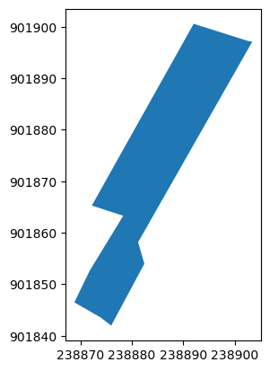

```python
fuelBoston[fuelBoston.element=='relation'].plot()
```

Let me get the schools:

```python
# Get schools in Boston
schools = ox.features_from_place("Boston, Massachusetts, USA",
                                tags={'amenity': 'school'})
schools.info()
```

```
<class 'geopandas.geodataframe.GeoDataFrame'>
MultiIndex: 272 entries, ('node', np.int64(257493925)) to ('way', np.int64(1417025273))
Data columns (total 98 columns):
 #   Column                   Non-Null Count  Dtype
---  ------                   --------------  -----
 0   geometry                 272 non-null    geometry
 1   addr:city                185 non-null    object
 2   addr:housenumber         197 non-null    object
 3   addr:postcode            188 non-null    object
 4   addr:state               166 non-null    object
 5   addr:street              198 non-null    object
 6   amenity                  272 non-null    object
 7   attribution              116 non-null    object
 8   gnis:feature_id          128 non-null    object
 9   jurisdiction             1 non-null      object
```

[output cut: 90 more lines]

Let's reformat this as we did before:

```python
schools.reset_index(inplace=True)
schoolBoston=schools[['element','name','geometry']].copy()
schoolBoston.fillna({'name':'Unknown'},inplace=True)
schoolBoston['newname']=schoolBoston.index.astype(str)+"_"+schoolBoston.name
schoolBoston.set_index('newname',inplace=True)
schoolBoston.drop(columns=['name'],inplace=True)
schoolBoston = schoolBoston.to_crs(Boston_crs)
schoolBoston.head()
```

| newname | element | geometry |
| --- | --- | --- |
| 0_Boston Police Academy | node | POINT (231587.542 888708.322) |
| 1_Urban Science Academy | node | POINT (226876.32 892442.908) |
| 2_Boston Middle School Academy | node | POINT (234181.887 894623.399) |
| 3_Ralph Waldo Emerson School | node | POINT (235209.779 897088.628) |
| 4_John Paul II Polish School | node | POINT (236451.673 897587.454) |

See element vs geo:

```python
pd.crosstab(schoolBoston.element,schoolBoston.geometry.geom_type, margins=True)
```

| col_0 element | MultiPolygon | Point | Polygon | All |
| --- | --- | --- | --- | --- |
| node | 0 | 113 | 0 | 113 |
| relation | 1 | 0 | 5 | 6 |
| way | 0 | 0 | 153 | 153 |
| All | 1 | 113 | 158 | 272 |

```python
#original data
schools[(schools.element=='relation') & (schools.geometry.geom_type=='MultiPolygon')]
```

|  | element | id | geometry | addr:city | addr:housenumber | addr:postcode | addr:state | addr:street | amenity | attribution | ... | twitter | max_age | min_age | official_name | name:etymology:wikidata | mascot | note | isced:level | wikipedia:en | office |
| --- | --- | --- | --- | --- | --- | --- | --- | --- | --- | --- | --- | --- | --- | --- | --- | --- | --- | --- | --- | --- | --- |
| 116 | relation | 3844332 | MULTIPOLYGON (((-71.16686 42.27773, -71.16687 ... | West Roxbury | 235 | 02132 | NaN | Baker Street | school | NaN | ... | NaN | NaN | NaN | NaN | NaN | NaN | NaN | NaN | NaN | NaN |

1 rows × 100 columns

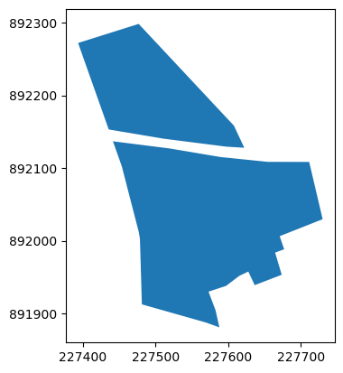

```python
schoolBoston[(schoolBoston.element=='relation') & (schoolBoston.geometry.geom_type=='MultiPolygon')].plot()
```

```python
base=boston.explore(tiles='cartodbpositron',color='lightblue')
schoolBoston.explore(m=base,color='k')
fuelBoston.explore(m=base,color='red')
```

Make this Notebook Trusted to load map: File -> Trust Notebook

[interactive chart not shown]

# Explore proximity:

Let's compute a couple of distance matrices.

- The distance among fuel stations

```python
D_Matrix_fuel_fuel=fuelBoston.geometry.apply\
(lambda station: fuelBoston.geometry.distance(station))

D_Matrix_fuel_fuel
```

| newname | 0_Unknown | 1_Shell | 2_Columbia Road Gulf | 3_Shell | 4_Unknown | 5_Speedway | 6_Speedway | 7_JP Oil | 8_Emporium Gas | 9_Shell | ... | 45_Stan Hatoff's | 46_Unknown | 47_Southie Gas | 48_Stop & Shop Gas | 49_Unknown | 50_Allston Gulf | 51_Shell | 52_Speedway | 53_Roger's Services | 54_Unknown |
| --- | --- | --- | --- | --- | --- | --- | --- | --- | --- | --- | --- | --- | --- | --- | --- | --- | --- | --- | --- | --- | --- |
| 0_Unknown | 0.000000 | 8727.624383 | 6871.952298 | 3407.837938 | 3673.165372 | 4209.712154 | 2813.964173 | 4201.365595 | 1790.404515 | 12155.739962 | ... | 3234.495836 | 6095.242575 | 8620.620270 | 6760.384459 | 4602.264652 | 9268.657342 | 7386.485428 | 5883.133123 | 4860.331859 | 3884.455796 |
| 1_Shell | 8727.624383 | 0.000000 | 7105.472646 | 7366.911850 | 10987.208647 | 11470.088910 | 8114.564055 | 4658.243433 | 6950.074505 | 7326.070600 | ... | 5867.405363 | 3305.372464 | 6111.383061 | 6245.483625 | 4335.437151 | 616.085382 | 4161.170067 | 10476.799257 | 13464.647569 | 7763.762976 |
| 2_Columbia Road Gulf | 6871.952298 | 7105.472646 | 0.000000 | 8574.756321 | 10519.035543 | 11064.397417 | 8655.942529 | 4696.391662 | 5785.564850 | 5859.694999 | ... | 4331.598353 | 4113.489962 | 2305.082433 | 842.480604 | 4470.888788 | 7684.987331 | 3013.288615 | 4137.188866 | 11158.757928 | 9232.804703 |
| 3_Shell | 3407.837938 | 7366.911850 | 8574.756321 | 0.000000 | 3720.444951 | 4155.568688 | 898.002993 | 4205.034626 | 3009.853106 | 12757.986963 | ... | 4214.095164 | 5977.659946 | 9649.672607 | 8137.399622 | 4593.183084 | 7756.624042 | 7816.711177 | 8895.324825 | 6750.299648 | 658.507965 |
| 4_Unknown | 3673.165372 | 10987.208647 | 10519.035543 | 3720.444951 | 0.000000 | 551.674425 | 2887.510892 | 7122.877723 | 4925.464710 | 15575.071746 | ... | 6537.960311 | 9075.109742 | 12142.358940 | 10345.864017 | 7552.207045 | 11415.891646 | 10668.029754 | 9280.123532 | 3439.078579 | 3554.262419 |
| 5_Speedway | 4209.712154 | 11470.088910 | 11064.397417 | 4155.568688 | 551.674425 | 0.000000 | 3356.249306 | 7662.016312 | 5476.509621 | 16125.184185 | ... | 7088.725747 | 9611.237999 | 12694.008878 | 10896.053762 | 8091.038429 | 11887.740132 | 11215.288798 | 9752.331375 | 3381.699322 | 3926.944945 |
| 6_Speedway | 2813.964173 | 8114.564055 | 8655.942529 | 898.002993 | 2887.510892 | 3356.249306 | 0.000000 | 4572.512317 | 2898.499218 | 13160.329148 | ... | 4333.507414 | 6451.824616 | 9921.847613 | 8299.281817 | 4987.120000 | 8532.628063 | 8205.612961 | 8552.623751 | 5852.337979 | 1113.725238 |
| 7_JP Oil | 4201.365595 | 4658.243433 | 4696.391662 | 4205.034626 | 7122.877723 | 7662.016312 | 4572.512317 | 0.000000 | 2419.748129 | 8588.937416 | ... | 1241.998185 | 1960.893741 | 5459.022652 | 4100.235410 | 429.647109 | 5241.060168 | 3634.318645 | 6544.428046 | 9050.593963 | 4833.315836 |
| 8_Emporium Gas | 1790.404515 | 6950.074505 | 5785.564850 | 3009.853106 | 4925.464710 | 5476.509621 | 2898.499218 | 2419.748129 | 0.000000 | 10652.080578 | ... | 1613.378546 | 4343.655419 | 7231.798174 | 5494.062792 | 2829.639930 | 7499.948706 | 5771.354957 | 5946.473052 | 6630.854709 | 3648.146781 |
| 9_Shell | 12155.739962 | 7326.070600 | 5859.694999 | 12757.986963 | 15575.071746 | 16125.184185 | 13160.329148 | 8588.937416 | 10652.080578 | 0.000000 | ... | 9022.483011 | 6774.589101 | 3607.101370 | 5539.856088 | 8167.336183 | 7572.694395 | 4943.083430 | 9781.300877 | 16792.843436 | 13357.391330 |
| 10_Mobil | 13406.427002 | 8452.326268 | 6974.418159 | 14043.510851 | 16847.787266 | 17398.324182 | 14445.328375 | 9874.331325 | 11923.094113 | 1285.853822 | ... | 10293.178624 | 8057.513700 | 4801.799045 | 6727.514379 | 9453.091740 | 8649.595560 | 6228.440515 | 10759.121853 | 18006.705495 | 14642.056845 |
| 11_Unknown | 14835.233534 | 10102.993288 | 8201.348636 | 15628.340924 | 18336.836677 | 18888.364668 | 16001.002134 | 11439.846265 | 13413.825439 | 2904.406828 | ... | 11786.925419 | 9664.387260 | 6191.356330 | 8071.098505 | 11025.976662 | 10284.734070 | 7801.342701 | 11727.181648 | 19338.893022 | 16235.509285 |
| 12_Gulf | 6025.088313 | 10565.043260 | 4166.843906 | 9036.244183 | 9417.545107 | 9888.771504 | 8694.824529 | 6662.028380 | 6085.279315 | 9782.834276 | ... | 5565.722650 | 7239.064894 | 6428.762271 | 4845.339897 | 6714.613440 | 11178.674608 | 6909.892788 | 108.648957 | 8748.493498 | 9637.124611 |
| 13_Unknown | 1062.590413 | 8315.179820 | 7406.977427 | 2360.966852 | 3186.076951 | 3737.600345 | 1756.153384 | 4045.997432 | 1742.212766 | 12394.251575 | ... | 3355.566638 | 6004.398150 | 8958.923789 | 7183.051905 | 4472.469861 | 8818.886789 | 7506.685743 | 6849.344753 | 5151.791659 | 2822.104558 |
| 14_Sunoco | 7499.682166 | 2938.326834 | 4194.401280 | 7373.686454 | 10519.349502 | 11055.218991 | 7879.925188 | 3403.060629 | 5768.011185 | 5500.619002 | ... | 4255.884064 | 1428.791366 | 3301.000396 | 3334.796870 | 2962.702785 | 3499.863054 | 1226.379666 | 7830.232666 | 12356.311161 | 7940.952850 |
| 15_Mobil | 13189.187038 | 7636.666874 | 7055.164740 | 13581.141529 | 16535.657938 | 17083.169204 | 14036.329109 | 9471.042750 | 11629.676449 | 1234.979828 | ... | 10005.362267 | 7580.815450 | 4764.115457 | 6687.602733 | 9038.789613 | 7787.280869 | 5854.275298 | 11010.294342 | 17883.994384 | 14159.960169 |
| 16_Shell | 11217.108854 | 5410.113488 | 5721.177963 | 11365.999912 | 14438.750848 | 14981.407966 | 11860.042715 | 7325.584861 | 9580.147239 | 1976.242657 | ... | 7977.916447 | 5387.701110 | 3421.104820 | 5147.884761 | 6886.953899 | 5620.185781 | 3815.188136 | 9850.613115 | 16003.072270 | 11930.508303 |
| 17_BP | 3363.484283 | 12064.072303 | 9580.267986 | 5734.207589 | 3123.265193 | 3326.009866 | 4854.883005 | 7563.846276 | 5152.840660 | 15205.896426 | ... | 6542.776852 | 9439.490523 | 11591.533762 | 9663.301442 | 7961.252603 | 12590.630333 | 10610.316110 | 7222.340240 | 1587.299860 | 5892.929545 |
| 18_Citgo | 5792.793293 | 3157.877032 | 4765.436338 | 5343.671271 | 8571.305427 | 9098.743386 | 5871.510097 | 1593.886583 | 4006.624299 | 7489.806036 | ... | 2734.741396 | 742.060433 | 4801.754421 | 3986.510975 | 1208.629547 | 3762.558961 | 2688.451713 | 7507.572899 | 10634.972998 | 5909.604358 |
| 19_Speedway | 8124.031788 | 699.692778 | 7010.276734 | 6672.548280 | 10304.365223 | 10783.668242 | 7427.486863 | 4134.533461 | 6359.010737 | 7769.641037 | ... | 5365.307429 | 3013.954459 | 6243.673045 | 6158.129435 | 3848.022905 | 1146.627045 | 4181.970953 | 10182.316098 | 12825.763775 | 7064.944166 |
| 20_Speedway | 11849.875855 | 4663.984912 | 7140.143221 | 11470.494998 | 14805.322639 | 15332.214392 | 12074.457213 | 7731.500659 | 10117.483111 | 3565.391587 | ... | 8599.936304 | 5760.117293 | 4969.805534 | 6454.187827 | 7294.336070 | 4675.859598 | 4675.102567 | 11264.816621 | 16703.794204 | 11975.017791 |
| 21_Irving | 8367.652608 | 837.381328 | 7462.319571 | 6742.476856 | 10412.213846 | 10879.692389 | 7526.533089 | 4462.739116 | 6620.468130 | 8118.395771 | ... | 5701.602708 | 3445.951531 | 6685.846217 | 6610.855891 | 4201.112178 | 1019.903444 | 4633.721847 | 10599.860375 | 13018.424897 | 7099.287570 |
| 22_Stop & Shop | 500.106762 | 9098.949106 | 6840.292728 | 3897.486105 | 3826.468615 | 4343.854027 | 3273.877369 | 4516.268945 | 2150.373903 | 12254.353821 | ... | 3464.146121 | 6364.871152 | 8682.703104 | 6790.982841 | 4902.234452 | 9650.307548 | 7558.829683 | 5556.997178 | 4624.760894 | 4358.487272 |
| 23_Cumberland Farms | 7473.489449 | 2914.754332 | 8377.165055 | 5173.449718 | 8893.092751 | 9314.179002 | 6035.379323 | 4321.725611 | 5897.499675 | 10020.342519 | ... | 5487.846328 | 4250.265378 | 8109.553236 | 7582.667616 | 4257.127107 | 3021.199093 | 5946.768334 | 10858.265404 | 11793.185827 | 5403.780282 |
| 24_Mobil | 7425.101937 | 1991.189323 | 7517.267156 | 5562.788155 | 9257.067735 | 9713.022602 | 6369.791536 | 3821.248363 | 5735.236458 | 8980.096986 | ... | 5049.329763 | 3372.343102 | 7114.926603 | 6699.956564 | 3662.367361 | 2238.171760 | 4963.421302 | 10254.951557 | 11964.426087 | 5895.563544 |
| 25_Sunoco | 3907.976441 | 10589.578219 | 5635.565368 | 7239.273417 | 6962.664015 | 7402.402554 | 6717.665875 | 6087.360895 | 4612.581820 | 11495.259125 | ... | 4817.732885 | 7324.483526 | 7905.318267 | 6027.563339 | 6302.316069 | 11198.622719 | 7679.060973 | 2488.973150 | 6148.392558 | 7765.840492 |
| 26_Sunoco | 1426.990148 | 9781.315313 | 6820.242309 | 4818.798426 | 4301.925756 | 4774.252715 | 4166.822778 | 5138.969055 | 2900.975256 | 12432.206530 | ... | 3978.279075 | 6888.034904 | 8815.049878 | 6886.498157 | 5494.706815 | 10349.072228 | 7900.202439 | 4979.358685 | 4363.923739 | 5263.504147 |
| 27_Shell - Nouria | 12177.704206 | 8129.512484 | 5573.839565 | 13069.224787 | 15693.182924 | 16244.846426 | 13404.823480 | 8866.170271 | 10774.656811 | 1093.893176 | ... | 9151.541982 | 7173.078761 | 3535.312309 | 5413.160868 | 8463.946489 | 8427.738863 | 5262.438103 | 9271.718279 | 16688.006215 | 13688.856790 |
| 28_BP | 13355.868119 | 8450.108652 | 6910.567529 | 14009.032927 | 16802.523200 | 17353.189265 | 14406.917712 | 9836.675017 | 11877.485785 | 1251.628357 | ... | 10247.588282 | 8026.048215 | 4745.532873 | 6669.577853 | 9416.378874 | 8652.415024 | 6190.938531 | 10687.617569 | 17950.291335 | 14608.953930 |
| 29_Speedway | 6902.050058 | 7054.763255 | 55.729518 | 8584.628133 | 10546.589201 | 11092.323511 | 8671.509057 | 4691.998988 | 5804.266556 | 5787.674508 | ... | 4342.392677 | 4079.623187 | 2231.003077 | 789.644184 | 4461.871755 | 7632.729644 | 2953.608231 | 4191.929686 | 11200.130157 | 9242.510328 |
| 30_Speedway | 8040.306786 | 6395.938813 | 1546.986585 | 9284.677140 | 11611.906150 | 12162.748483 | 9497.618678 | 5146.450766 | 6734.820980 | 4320.755416 | ... | 5149.567981 | 3947.749465 | 732.948632 | 1248.458256 | 4813.487271 | 6923.038822 | 2251.303927 | 5651.095554 | 12522.732322 | 9931.765835 |
| 31_Sunoco | 6960.060616 | 5419.678113 | 1675.029558 | 7964.665146 | 10446.105397 | 10997.763378 | 8217.916891 | 3798.638994 | 5529.033541 | 5190.987386 | ... | 3910.740160 | 2646.721785 | 1686.665809 | 827.393404 | 3456.958325 | 5990.009329 | 1301.614319 | 5589.702331 | 11598.310753 | 8606.792932 |
| 32_Gulf | 7291.449090 | 4266.672182 | 2895.434651 | 7770.217640 | 10591.128360 | 11139.038537 | 8146.944674 | 3579.008873 | 5687.850751 | 5006.956758 | ... | 4068.680133 | 1916.406177 | 2124.974171 | 2045.367953 | 3165.026235 | 4824.015103 | 123.694424 | 6720.768899 | 12075.471421 | 8384.420360 |
| 33_Mobil | 4875.805051 | 13534.453758 | 11039.336960 | 6926.121255 | 3709.666761 | 3682.608559 | 6028.744062 | 9076.283161 | 6659.240975 | 16710.675117 | ... | 8071.873784 | 10963.941781 | 13088.811064 | 11155.575193 | 9478.008257 | 14049.235250 | 12140.144888 | 8411.848981 | 335.262832 | 6978.812604 |
| 34_Gulf | 9261.542498 | 607.870723 | 7677.189761 | 7751.177694 | 11410.062257 | 11882.038819 | 8526.881515 | 5233.269931 | 7492.593076 | 7569.156325 | ... | 6451.197157 | 3913.158885 | 6594.922986 | 6816.696301 | 4921.905360 | 0.000000 | 4705.705707 | 11082.767636 | 13963.978048 | 8113.638361 |
| 35_Gulf | 8810.817204 | 1921.789297 | 8601.332862 | 6734.490175 | 10454.226257 | 10885.127428 | 7581.709202 | 5210.282422 | 7138.693845 | 9243.374818 | ... | 6445.385976 | 4511.028117 | 7893.186579 | 7757.561508 | 5022.690900 | 1728.030359 | 5826.910800 | 11568.877407 | 13278.322543 | 6987.698294 |
| 36_Oak Square Sunoco | 8758.587071 | 3486.736261 | 9696.253027 | 6170.449458 | 9841.419144 | 10219.739641 | 7061.990590 | 5742.256879 | 7247.907657 | 10810.092733 | ... | 6905.461711 | 5551.324246 | 9247.989917 | 8882.228837 | 5670.583172 | 3327.477404 | 7116.935109 | 12276.539983 | 12897.729098 | 6282.310325 |
| 37_US Gas | 6214.382345 | 7348.502002 | 752.814827 | 8114.252338 | 9878.355272 | 10420.072335 | 8133.336633 | 4433.920260 | 5240.017038 | 6608.888331 | ... | 3885.627041 | 4184.051494 | 3030.504322 | 1297.244416 | 4272.634808 | 7945.309747 | 3415.305073 | 3490.890323 | 10418.968623 | 8772.412913 |
| 38_Unknown | 7039.098516 | 5444.326991 | 1689.542365 | 8048.021614 | 10528.157629 | 11079.821621 | 8301.693987 | 3880.702856 | 5611.672793 | 5105.486179 | ... | 3993.883183 | 2710.465761 | 1602.360724 | 853.440108 | 3537.509980 | 6010.871061 | 1305.196059 | 5636.578385 | 11677.526135 | 8689.988860 |
| 39_Shell | 7567.166899 | 2905.740442 | 4219.882700 | 7430.474500 | 10583.039568 | 11118.614522 | 7940.061721 | 3467.923130 | 5834.769077 | 5432.697981 | ... | 4323.713111 | 1493.252625 | 3279.989905 | 3361.263803 | 3027.680151 | 3461.658685 | 1232.469961 | 7880.091938 | 12423.944209 | 7996.031926 |
| 40_Gibbs Gas Station | 3946.356739 | 4860.148174 | 4791.608900 | 3980.548783 | 6859.123220 | 7398.825918 | 4324.821956 | 240.853174 | 2161.575618 | 8802.870992 | ... | 1079.700455 | 2200.052836 | 5637.084052 | 4225.999564 | 667.721332 | 5436.680344 | 3848.394463 | 6472.680704 | 8792.092291 | 4615.151116 |
| 41_Unknown | 6401.341519 | 10594.139121 | 4004.737720 | 9355.267561 | 9827.153050 | 10302.609103 | 9040.133363 | 6824.420424 | 6382.516153 | 9507.110816 | ... | 5771.329190 | 7286.850711 | 6224.028760 | 4729.426780 | 6850.999624 | 11205.074499 | 6840.035148 | 527.066662 | 9185.021642 | 9964.219382 |
| 42_Citgo | 6089.048907 | 9443.443223 | 2834.017033 | 8763.091165 | 9674.363747 | 10179.567995 | 8550.041763 | 5857.405535 | 5753.776152 | 8470.010274 | ... | 4905.826101 | 6158.528093 | 5089.863689 | 3540.812841 | 5838.917874 | 10051.760595 | 5649.608963 | 1299.844196 | 9455.274994 | 9396.104273 |
| 43_Unknown | 0.000000 | 8723.005645 | 6864.474310 | 3398.979004 | 3664.094802 | 4200.713758 | 2805.218583 | 4198.198987 | 1786.634948 | 12149.546172 | ... | 3229.743156 | 6091.379122 | 8613.990208 | 6753.413715 | 4598.890949 | 9263.781903 | 7381.139255 | 5874.971613 | 4855.369360 | 3875.610294 |
| 44_JP Gas | 4013.495631 | 4804.131369 | 4779.999585 | 4037.165041 | 6928.182608 | 7467.672230 | 4388.516996 | 182.215747 | 2229.405984 | 8756.552753 | ... | 1125.806145 | 2142.907708 | 5602.217504 | 4205.966513 | 611.126871 | 5382.263577 | 3801.815126 | 6503.202595 | 8860.079194 | 4669.995649 |
| 45_Stan Hatoff's | 3234.495836 | 5867.405363 | 4331.598353 | 4214.095164 | 6537.960311 | 7088.725747 | 4333.507414 | 1241.998185 | 1613.378546 | 9022.483011 | ... | 0.000000 | 2886.055960 | 5617.245894 | 3939.744916 | 1520.242884 | 6459.089608 | 4156.095309 | 5440.365730 | 8079.200249 | 4872.370145 |
| 46_Unknown | 6095.242575 | 3305.372464 | 4113.489962 | 5977.659946 | 9075.109742 | 9611.237999 | 6451.824616 | 1960.893741 | 4343.655419 | 6774.589101 | ... | 2886.055960 | 0.000000 | 4027.800235 | 3302.627844 | 1521.005148 | 3921.374144 | 1919.534927 | 7147.365057 | 10955.572489 | 6563.627078 |
| 47_Southie Gas | 8620.620270 | 6111.383061 | 2305.082433 | 9649.672607 | 12142.358940 | 12694.008878 | 9921.847613 | 5459.022652 | 7231.798174 | 3607.101370 | ... | 5617.245894 | 4027.800235 | 0.000000 | 1905.315511 | 5090.195076 | 6601.657977 | 2152.064341 | 6407.946406 | 13178.800624 | 10286.773023 |
| 48_Stop & Shop Gas | 6760.384459 | 6245.483625 | 842.480604 | 8137.399622 | 10345.864017 | 10896.053762 | 8299.281817 | 4100.235410 | 5494.062792 | 5539.856088 | ... | 3939.744916 | 3302.627844 | 1905.315511 | 0.000000 | 3824.181094 | 6824.492476 | 2166.466056 | 4802.649318 | 11250.154462 | 8790.959887 |
| 49_Unknown | 4602.264652 | 4335.437151 | 4470.888788 | 4593.183084 | 7552.207045 | 8091.038429 | 4987.120000 | 429.647109 | 2829.639930 | 8167.336183 | ... | 1520.242884 | 1521.005148 | 5090.195076 | 3824.181094 | 0.000000 | 4929.841014 | 3215.252598 | 6602.411633 | 9457.750926 | 5212.560101 |
| 50_Allston Gulf | 9268.657342 | 616.085382 | 7684.987331 | 7756.624042 | 11415.891646 | 11887.740132 | 8532.628063 | 5241.060168 | 7499.948706 | 7572.694395 | ... | 6459.089608 | 3921.374144 | 6601.657977 | 6824.492476 | 4929.841014 | 0.000000 | 4713.213296 | 11090.965884 | 13970.645718 | 8118.685181 |
| 51_Shell | 7386.485428 | 4161.170067 | 3013.288615 | 7816.711177 | 10668.029754 | 11215.288798 | 8205.612961 | 3634.318645 | 5771.354957 | 4943.083430 | ... | 4156.095309 | 1919.534927 | 2152.064341 | 2166.466056 | 3215.252598 | 4713.213296 | 0.000000 | 6850.839417 | 12178.136611 | 8426.955214 |
| 52_Speedway | 5883.133123 | 10476.799257 | 4137.188866 | 8895.324825 | 9280.123532 | 9752.331375 | 8552.623751 | 6544.428046 | 5946.473052 | 9781.300877 | ... | 5440.365730 | 7147.365057 | 6407.946406 | 4802.649318 | 6602.411633 | 11090.965884 | 6850.839417 | 0.000000 | 8631.124198 | 9495.674957 |
| 53_Roger's Services | 4860.331859 | 13464.647569 | 11158.757928 | 6750.299648 | 3439.078579 | 3381.699322 | 5852.337979 | 9050.593963 | 6630.854709 | 16792.843436 | ... | 8079.200249 | 10955.572489 | 13178.800624 | 11250.154462 | 9457.750926 | 13970.645718 | 12178.136611 | 8631.124198 | 0.000000 | 6774.701627 |
| 54_Unknown | 3884.455796 | 7763.762976 | 9232.804703 | 658.507965 | 3554.262419 | 3926.944945 | 1113.725238 | 4833.315836 | 3648.146781 | 13357.391330 | ... | 4872.370145 | 6563.627078 | 10286.773023 | 8790.959887 | 5212.560101 | 8118.685181 | 8426.955214 | 9495.674957 | 6774.701627 | 0.000000 |

55 rows × 55 columns

From here, we can compute the minimal distance among those gas stations:

```python
D_Matrix_fuel_fuel.replace(0,None,inplace=True) # avoid the zero
D_Matrix_fuel_fuel.min(axis=1).sort_values().head(10)
```

```
newname
40_Gibbs Gas Station    48.487191
44_JP Gas               48.487191
29_Speedway             55.729518
2_Columbia Road Gulf    55.729518
31_Sunoco               66.650839
38_Unknown              66.650839
14_Sunoco               67.991699
39_Shell                67.991699
10_Mobil                69.527035
28_BP                   69.527035
dtype: object
```

- The distance among gas stations and schools:

```python
D_Matrix_fuel_school=fuelBoston.geometry.apply\
(lambda station: schoolBoston.geometry.distance(station))

D_Matrix_fuel_school
```

| newname | 0_Boston Police Academy | 1_Urban Science Academy | 2_Boston Middle School Academy | 3_Ralph Waldo Emerson School | 4_John Paul II Polish School | 5_Academy Of the Pacific Rim Charter Public School | 6_Smith Leadership Academy Charter Public School | 7_The Learning Project Elementary School | 8_Lyndon | 9_Eliot Elementary | ... | 262_Maurice J Tobin School | 263_William Ellery Channing | 264_Emily A Fifield School | 265_Sarah Greenwood School | 266_Joyce Kilmer School | 267_Robert Gould Shaw Middle School | 268_Frank W Thompson Middle School | 269_Josiah Quincy Elementary School | 270_Josiah Quincy Upper School | 271_Italian Home for Children School |
| --- | --- | --- | --- | --- | --- | --- | --- | --- | --- | --- | --- | --- | --- | --- | --- | --- | --- | --- | --- | --- | --- |
| 0_Unknown | 3517.172373 | 4538.314533 | 3668.709777 | 6175.633927 | 7363.805994 | 3955.280914 | 5531.851825 | 8892.716105 | 3078.082221 | 11011.884118 | ... | 6094.027891 | 3311.861500 | 3877.485852 | 3696.466905 | 3648.966085 | 3204.880248 | 3107.703357 | 8744.745535 | 8763.768694 | 2519.578877 |
| 1_Shell | 12244.290100 | 9343.647624 | 7157.251605 | 5852.503222 | 6571.745828 | 12526.745937 | 8427.175998 | 4082.135425 | 7593.700123 | 6065.516344 | ... | 3577.824538 | 11821.405873 | 9043.357522 | 7751.590351 | 10007.607833 | 8728.125278 | 9298.057232 | 5126.352377 | 5244.669476 | 6028.525154 |
| 2_Columbia Road Gulf | 9473.181799 | 10605.020433 | 3203.648108 | 1383.419611 | 820.705094 | 10411.205910 | 2152.076759 | 4033.072522 | 8484.410901 | 5060.790603 | ... | 3681.523118 | 9914.982628 | 3946.474058 | 3206.964180 | 10249.275203 | 9342.070973 | 4752.045981 | 3060.289866 | 3001.370974 | 6018.628205 |
| 3_Shell | 6090.044288 | 2180.682657 | 5758.089941 | 7444.959838 | 8781.563134 | 5845.185924 | 7955.167693 | 9097.280039 | 368.378525 | 11471.081097 | ... | 6180.145729 | 5140.207328 | 6796.810108 | 6117.847196 | 2645.098933 | 1366.297789 | 6237.546105 | 9379.137516 | 9436.950650 | 2315.987018 |
| 4_Unknown | 3591.058820 | 2656.779444 | 7324.527882 | 9722.650156 | 10966.471948 | 2720.954364 | 9187.416199 | 12106.466319 | 3432.549911 | 14365.388885 | ... | 9175.679742 | 2209.520760 | 7420.389293 | 7367.528360 | 1164.308095 | 2283.368252 | 6557.039305 | 12135.911449 | 12169.615827 | 5097.389773 |
| 5_Speedway | 3795.183476 | 2843.577257 | 7867.642325 | 10273.832679 | 11515.960465 | 2784.007788 | 9711.387849 | 12650.106349 | 3888.425893 | 14913.672863 | ... | 9716.552271 | 2377.773585 | 7921.808041 | 7899.815126 | 1466.066277 | 2688.826633 | 7049.037738 | 12685.902982 | 12719.957550 | 5635.160194 |
| 6_Speedway | 5222.069546 | 1958.824895 | 5667.363486 | 7620.966318 | 8942.451556 | 4947.709018 | 7815.937994 | 9556.758148 | 558.089978 | 11897.024151 | ... | 6612.252164 | 4243.943678 | 6472.132841 | 5949.102681 | 1939.012041 | 729.211464 | 5821.401338 | 9743.653141 | 9792.926447 | 2552.817236 |
| 7_JP Oil | 7693.440150 | 6373.595359 | 2909.009606 | 3405.277505 | 4728.536028 | 8131.470068 | 4848.386353 | 5002.611327 | 4228.078505 | 7325.295482 | ... | 2057.725566 | 7457.504144 | 4731.039491 | 3506.146738 | 6454.917222 | 5301.682850 | 4782.993855 | 5183.102452 | 5237.459061 | 1899.450800 |
| 8_Emporium Gas | 5303.105183 | 4857.317730 | 2776.611052 | 4840.864788 | 6129.893860 | 5712.458287 | 4954.791044 | 7244.811933 | 2824.351629 | 9454.617256 | ... | 4373.723192 | 5042.700192 | 3853.665647 | 3108.466172 | 4488.656268 | 3563.095519 | 3435.568293 | 7214.053460 | 7245.923486 | 932.157757 |
| 9_Shell | 15157.800501 | 14938.190513 | 8701.081274 | 6035.637704 | 5102.936681 | 15977.085163 | 7990.823376 | 3720.893692 | 12809.569431 | 1326.803963 | ... | 6450.339540 | 15409.283805 | 9795.864766 | 8908.669623 | 15018.745338 | 13889.526123 | 10568.544008 | 3324.605580 | 3348.450704 | 10446.347546 |
| 10_Mobil | 16358.216923 | 16223.796610 | 9912.239362 | 7259.516736 | 6253.604698 | 17202.552228 | 9069.540692 | 4992.039657 | 14095.409985 | 2591.183867 | ... | 7735.834548 | 16644.956693 | 10920.833769 | 10088.640329 | 16300.926585 | 15174.505989 | 11717.145264 | 4600.450305 | 4620.055522 | 11729.335475 |
| 11_Unknown | 17665.843541 | 17806.224681 | 11267.870880 | 8660.220854 | 7547.343066 | 18562.201102 | 10209.974545 | 6625.036163 | 15667.503517 | 4229.398793 | ... | 9326.617347 | 18029.472332 | 12115.838624 | 11384.840066 | 17833.246470 | 16729.404326 | 12946.646699 | 6139.351398 | 6139.098770 | 13271.598347 |
| 12_Gulf | 7061.719562 | 10542.249902 | 3764.423343 | 4915.236453 | 4985.405753 | 8256.768278 | 2187.156643 | 8145.088645 | 8791.063911 | 9154.267301 | ... | 6900.982275 | 7980.560362 | 2158.087423 | 3093.487667 | 9642.659507 | 9195.150779 | 2804.160045 | 7226.855052 | 7167.795316 | 6861.453393 |
| 13_Unknown | 4080.652814 | 3552.318815 | 4258.513802 | 6547.761693 | 7810.830433 | 4212.735709 | 6294.684573 | 8968.403063 | 2022.394872 | 11195.029710 | ... | 6066.833412 | 3506.253903 | 4794.543074 | 4426.511742 | 2859.583876 | 2203.765442 | 4092.824609 | 8956.255830 | 8988.050881 | 2086.652789 |
| 14_Sunoco | 10901.121494 | 9547.031834 | 4916.263311 | 3024.495784 | 3633.886009 | 11454.883135 | 5719.380585 | 1779.822391 | 7470.632454 | 4178.990080 | ... | 1302.815515 | 10800.943761 | 6699.269352 | 5443.752540 | 9802.088107 | 8600.337898 | 7141.617672 | 2474.947357 | 2575.803057 | 5281.489388 |
| 15_Mobil | 16267.701995 | 15759.724979 | 9809.795464 | 7138.911343 | 6281.756881 | 17052.095638 | 9196.337995 | 4484.759963 | 13657.720960 | 2178.043408 | ... | 7300.478084 | 16467.841602 | 10976.246800 | 10050.472270 | 15925.122980 | 14764.377170 | 11732.384264 | 4338.989491 | 4379.246011 | 11355.778273 |
| 16_Shell | 14440.714880 | 13538.623725 | 8045.073267 | 5431.368540 | 4900.826755 | 15139.065585 | 7848.250585 | 2335.847278 | 11460.134212 | 1031.154538 | ... | 5150.149323 | 14523.926922 | 9447.003876 | 8383.189897 | 13770.819093 | 12584.674411 | 10119.384290 | 2598.103518 | 2678.807685 | 9223.983348 |
| 17_BP | 469.874927 | 5568.452607 | 6507.360866 | 9170.563797 | 10207.178933 | 910.603723 | 7789.880834 | 12133.280446 | 5368.629983 | 14136.663208 | ... | 9415.239171 | 871.861479 | 5790.975027 | 6258.060622 | 4091.088548 | 4702.632816 | 4857.998144 | 11866.660524 | 11872.022411 | 5811.015090 |
| 18_Citgo | 9287.278497 | 7515.677654 | 4038.636839 | 3382.781979 | 4520.602291 | 9712.029987 | 5569.294698 | 3782.275533 | 5448.183292 | 6179.044446 | ... | 1093.176517 | 9031.682061 | 5928.878784 | 4642.067980 | 7803.799953 | 6584.407469 | 6143.338332 | 4246.943613 | 4326.357891 | 3335.629921 |
| 19_Speedway | 11636.466247 | 8643.970638 | 6763.627624 | 5701.428919 | 6543.137544 | 11886.671985 | 8176.569843 | 4350.336470 | 6903.398282 | 6479.914324 | ... | 3345.218196 | 11178.333924 | 8654.004798 | 7366.162852 | 9314.785039 | 8035.066321 | 8852.131194 | 5325.496654 | 5436.087927 | 5397.904103 |
| 20_Speedway | 15226.793161 | 13592.706757 | 9022.401992 | 6577.563595 | 6329.975072 | 15805.143089 | 9187.329625 | 3222.654419 | 11619.547137 | 2849.093175 | ... | 5649.308323 | 15152.349694 | 10612.575939 | 9450.846559 | 14013.429475 | 12768.473215 | 11197.655911 | 3957.887136 | 4070.471585 | 9566.877834 |
| 21_Irving | 11870.225982 | 8655.112492 | 7151.432770 | 6149.593725 | 6997.135648 | 12078.439914 | 8606.580036 | 4761.372353 | 6991.622209 | 6841.740915 | ... | 3786.726545 | 11366.331400 | 9040.581048 | 7756.178352 | 9387.440924 | 8108.650793 | 9212.406327 | 5756.140801 | 5867.555582 | 5616.827699 |
| 22_Stop & Shop | 3178.472883 | 4931.935145 | 3647.903527 | 6237.554989 | 7377.113881 | 3751.385573 | 5369.513628 | 9076.627831 | 3562.568336 | 11139.663419 | ... | 6336.606471 | 3155.690495 | 3611.468853 | 3583.076503 | 3944.743020 | 3617.465927 | 2785.020201 | 8867.820052 | 8880.823337 | 2949.322087 |
| 23_Cumberland Farms | 10846.887662 | 6864.922996 | 7230.255654 | 6996.060967 | 8084.233635 | 10861.032078 | 9063.678669 | 6465.431190 | 5478.463620 | 8712.533857 | ... | 4637.192640 | 10142.964928 | 9038.492383 | 7827.741164 | 7766.138990 | 6514.058992 | 8997.074516 | 7315.287155 | 7417.726609 | 4741.600117 |
| 24_Mobil | 10890.973833 | 7440.036706 | 6679.146972 | 6147.512759 | 7171.189445 | 11025.103594 | 8370.224001 | 5426.821599 | 5826.585929 | 7670.978354 | ... | 3757.354118 | 10308.910435 | 8538.789841 | 7285.637920 | 8204.164456 | 6928.303712 | 8596.964075 | 6294.599014 | 6398.622268 | 4652.579764 |
| 25_Sunoco | 4453.194738 | 8409.017121 | 3476.300224 | 5786.773865 | 6407.541087 | 5645.988876 | 3529.982180 | 9129.590162 | 6936.720757 | 10645.304163 | ... | 7103.227477 | 5386.051875 | 1679.654554 | 2848.877943 | 7338.236011 | 7097.093688 | 1212.295980 | 8480.081207 | 8458.935621 | 5535.075763 |
| 26_Sunoco | 2741.032166 | 5734.608308 | 3731.681987 | 6398.351227 | 7433.274499 | 3590.965667 | 5126.545435 | 9426.361878 | 4479.473865 | 11375.948821 | ... | 6813.742937 | 3116.655092 | 3203.495510 | 3496.191250 | 4625.607423 | 4454.510554 | 2299.156110 | 9109.382467 | 9111.545638 | 3769.668170 |
| 27_Shell - Nouria | 15020.456582 | 15239.672347 | 8610.477925 | 6002.151899 | 4896.753743 | 15906.284198 | 7630.384998 | 4270.076935 | 13090.676331 | 2079.351431 | ... | 6804.560366 | 15370.816480 | 9509.932962 | 8738.925849 | 15214.345956 | 14131.388355 | 10325.826598 | 3579.237735 | 3555.472839 | 10667.357805 |
| 28_BP | 16300.299809 | 16189.100233 | 9856.124012 | 7205.522731 | 6192.617515 | 17147.700673 | 9002.943310 | 4965.803728 | 14059.111417 | 2565.446437 | ... | 7701.500475 | 16591.634527 | 10856.816064 | 10029.189185 | 16259.935716 | 15136.054949 | 11654.774739 | 4557.575463 | 4575.089266 | 11689.041224 |
| 29_Speedway | 9515.762040 | 10619.449608 | 3234.481507 | 1359.159815 | 746.108903 | 10450.482475 | 2206.848301 | 3962.142720 | 8496.597788 | 4986.743467 | ... | 3645.423487 | 9952.394317 | 3996.071601 | 3246.632657 | 10271.096854 | 9359.105692 | 4799.092134 | 2986.062582 | 2926.905917 | 6028.603654 |
| 30_Speedway | 10861.777471 | 11404.312305 | 4443.451309 | 1894.149549 | 756.912965 | 11738.439630 | 3698.938586 | 2752.903001 | 9249.845481 | 3487.169912 | ... | 3497.923524 | 11206.237466 | 5452.037058 | 4585.344088 | 11219.332919 | 10211.055035 | 6223.191361 | 1611.022734 | 1523.548111 | 6770.896632 |
| 31_Sunoco | 9982.303122 | 10102.553945 | 3529.201636 | 873.919071 | 1143.303517 | 10773.851891 | 3476.035524 | 2494.772138 | 7945.582764 | 4113.293273 | ... | 2194.249960 | 10203.539979 | 4904.422901 | 3827.606474 | 9986.119485 | 8938.241302 | 5561.304523 | 1853.788922 | 1853.061923 | 5479.332736 |
| 32_Gulf | 10526.096257 | 9946.115422 | 4210.407014 | 1869.245772 | 2299.456556 | 11209.502178 | 4596.180935 | 1628.776771 | 7806.070835 | 3766.928111 | ... | 1510.502428 | 10595.609382 | 5824.580001 | 4637.582532 | 10005.614998 | 8876.044838 | 6382.904414 | 1602.708751 | 1665.881603 | 5432.357621 |
| 33_Mobil | 1566.409581 | 6354.217393 | 8009.632168 | 10678.153618 | 11687.207035 | 1081.144035 | 9181.220400 | 13663.626694 | 6572.063602 | 15654.132144 | ... | 10944.227158 | 1703.950601 | 7166.200041 | 7728.042903 | 4842.404083 | 5720.981395 | 6241.745613 | 13385.836577 | 13389.440743 | 7277.507903 |
| 34_Gulf | 12775.055069 | 9670.026842 | 7762.744009 | 6440.406572 | 7123.485124 | 13024.695138 | 9029.422142 | 4501.641932 | 7995.407712 | 6346.377003 | ... | 4182.349863 | 12315.695260 | 9649.570629 | 8357.866816 | 10396.262662 | 9116.937195 | 9897.303825 | 5575.924257 | 5698.292945 | 6537.619508 |
| 35_Gulf | 12254.991966 | 8455.245405 | 8033.198954 | 7264.789243 | 8167.702765 | 12341.423011 | 9630.401253 | 5960.494374 | 7027.721751 | 7987.149020 | ... | 4876.384735 | 11623.507376 | 9906.290063 | 8640.761758 | 9344.123246 | 8085.027921 | 9992.322071 | 6964.438505 | 7076.017540 | 6040.098125 |
| 36_Oak Square Sunoco | 12053.366280 | 7594.663390 | 8650.558444 | 8322.831686 | 9353.465224 | 11977.257985 | 10465.304778 | 7431.529977 | 6506.284858 | 9538.848474 | ... | 5937.364058 | 11262.698270 | 10457.935571 | 9248.333121 | 8649.829672 | 7448.975185 | 10404.394062 | 8377.970314 | 8486.078025 | 6075.423821 |
| 37_US Gas | 8727.556448 | 10090.586422 | 2556.080511 | 1496.998048 | 1529.699570 | 9683.626341 | 1424.514877 | 4596.938533 | 7998.520555 | 5784.443376 | ... | 3779.219917 | 9199.579941 | 3180.924768 | 2485.682779 | 9661.000874 | 8802.733473 | 3990.142907 | 3716.218260 | 3670.467286 | 5567.616082 |
| 38_Unknown | 10061.196325 | 10186.215670 | 3607.646402 | 949.118816 | 1124.605344 | 10853.159342 | 3526.404312 | 2452.724855 | 8029.237252 | 4035.639052 | ... | 2257.904359 | 10282.805113 | 4972.680812 | 3902.554426 | 10069.524830 | 9022.004951 | 5634.437689 | 1780.614067 | 1778.773488 | 5563.106622 |
| 39_Shell | 10969.094155 | 9602.990813 | 4981.065332 | 3065.479020 | 3647.419520 | 11522.343595 | 5767.006174 | 1713.049354 | 7529.137742 | 4109.779934 | ... | 1370.715097 | 10868.154742 | 6761.432991 | 5506.880218 | 9863.224424 | 8659.766844 | 7206.268377 | 2435.865492 | 2538.250128 | 5344.493879 |
| 40_Gibbs Gas Station | 7443.863806 | 6142.119235 | 2829.710284 | 3528.577838 | 4860.210314 | 7871.680833 | 4834.488480 | 5230.879271 | 3991.727314 | 7544.625527 | ... | 2289.116941 | 7196.036176 | 4616.389130 | 3416.789351 | 6199.230896 | 5054.000282 | 4626.627231 | 5389.243430 | 5441.221417 | 1637.555113 |
| 41_Unknown | 7498.405426 | 10904.079985 | 3955.871282 | 4861.982254 | 4814.341292 | 8692.501906 | 2168.182849 | 8020.880805 | 9119.126182 | 8924.897840 | ... | 6933.281345 | 8412.403366 | 2492.324811 | 3311.067931 | 10030.554717 | 9555.357482 | 3192.074497 | 7058.888144 | 6993.020811 | 7128.010901 |
| 42_Citgo | 7740.401250 | 10470.159272 | 3105.659602 | 3675.815639 | 3650.422547 | 8863.496353 | 1037.241800 | 6835.715010 | 8561.494145 | 7818.181300 | ... | 5792.060795 | 8502.550557 | 2192.323974 | 2560.186717 | 9734.682015 | 9123.995803 | 3055.652203 | 5894.029483 | 5832.840476 | 6395.273943 |
| 43_Unknown | 3511.767409 | 4529.754693 | 3661.196080 | 6168.946268 | 7356.695153 | 3949.871989 | 5523.669728 | 8887.565095 | 3069.212002 | 11006.023132 | ... | 6089.698911 | 3305.807585 | 3869.188096 | 3688.425853 | 3639.717667 | 3196.533158 | 3099.577923 | 8738.794542 | 8757.745976 | 2513.769358 |
| 44_JP Gas | 7509.760031 | 6200.978894 | 2860.890588 | 3509.017589 | 4838.670345 | 7940.066771 | 4852.277843 | 5179.105127 | 4051.910698 | 7496.343911 | ... | 2235.884643 | 7265.030870 | 4655.342686 | 3450.331129 | 6265.513591 | 5117.724588 | 4673.473838 | 5345.482965 | 5398.247759 | 1705.921563 |
| 45_Stan Hatoff's | 6625.150508 | 6263.984425 | 1817.912100 | 3264.163426 | 4582.905439 | 7185.551984 | 3956.164444 | 5646.468407 | 4127.927307 | 7829.141450 | ... | 2846.561671 | 6546.052437 | 3525.668963 | 2372.027824 | 6056.268780 | 5040.911815 | 3514.503575 | 5585.054441 | 5616.232681 | 1658.227631 |
| 46_Unknown | 9535.740013 | 8157.211643 | 3856.897135 | 2745.645425 | 3804.181282 | 10046.658275 | 5129.053950 | 3096.225968 | 6056.797605 | 5475.265061 | ... | 354.643085 | 9384.561295 | 5728.505034 | 4438.716207 | 8366.684497 | 7176.519780 | 6052.049378 | 3486.069647 | 3562.587620 | 3838.485615 |
| 47_Southie Gas | 11532.102708 | 11797.575407 | 5084.633059 | 2446.471344 | 1501.029845 | 12378.173659 | 4456.090927 | 2221.287806 | 9640.770096 | 2725.837747 | ... | 3596.749074 | 11829.009854 | 6185.991700 | 5273.961186 | 11693.675790 | 10643.385878 | 6940.462037 | 998.007068 | 880.619851 | 7181.861244 |
| 48_Stop & Shop Gas | 9597.003325 | 10225.535929 | 3162.983571 | 697.924304 | 609.914754 | 10459.692061 | 2712.189665 | 3282.180280 | 8079.613020 | 4597.199824 | ... | 2861.326863 | 9923.997876 | 4290.999422 | 3335.984329 | 9982.715691 | 9004.705282 | 5016.477254 | 2438.257919 | 2407.364198 | 5596.302919 |
| 49_Unknown | 8080.699543 | 6768.135967 | 3006.427833 | 3138.662628 | 4439.073985 | 8541.719646 | 4813.759375 | 4566.333914 | 4630.206641 | 6897.657674 | ... | 1619.815199 | 7871.612586 | 4872.644583 | 3613.027499 | 6877.456855 | 5715.941687 | 4999.300186 | 4773.148491 | 4830.782030 | 2327.448123 |
| 50_Allston Gulf | 12782.066700 | 9674.770637 | 7770.920368 | 6448.401569 | 7131.045038 | 13031.351513 | 9037.579379 | 4507.675589 | 8001.045088 | 6350.574708 | ... | 4190.535855 | 12322.314928 | 9657.756985 | 8366.054365 | 10401.713817 | 9122.408513 | 9905.392454 | 5582.271124 | 5704.685079 | 6544.448882 |
| 51_Shell | 10633.861540 | 9994.396431 | 4331.026866 | 1999.731457 | 2402.117492 | 11309.539124 | 4726.284266 | 1509.018929 | 7858.239973 | 3690.135831 | ... | 1531.297899 | 10692.742725 | 5952.889733 | 4762.957415 | 10071.358216 | 8934.819198 | 6507.581191 | 1563.738295 | 1634.019972 | 5497.921282 |
| 52_Speedway | 6941.368375 | 10399.912991 | 3643.149061 | 4853.510105 | 4956.925220 | 8132.648890 | 2124.622077 | 8101.763488 | 8649.583659 | 9139.043728 | ... | 6813.460329 | 7851.824698 | 2017.124032 | 2968.100815 | 9501.662611 | 9052.794529 | 2662.757289 | 7195.802109 | 7138.546230 | 6726.118214 |
| 53_Roger's Services | 1717.140716 | 6092.705327 | 8094.660086 | 10757.359535 | 11791.988203 | 940.055176 | 9335.397170 | 13698.678252 | 6401.193779 | 15719.870538 | ... | 10948.551533 | 1567.217528 | 7325.215404 | 7839.219201 | 4584.880290 | 5506.906846 | 6395.901991 | 13449.086134 | 13455.472762 | 7213.789938 |
| 54_Unknown | 6279.229318 | 1605.399483 | 6407.161770 | 8097.652678 | 9434.874568 | 5901.552702 | 8600.123875 | 9680.272568 | 846.256709 | 12063.404051 | ... | 6780.911809 | 5218.269315 | 7399.950848 | 6756.128902 | 2360.751498 | 1178.925661 | 6808.751484 | 9994.225510 | 10054.408710 | 2972.698228 |

55 rows × 272 columns

# Decision 1: Find the stations that should go away

Now, we could compute the minimal distance from a gas station to a school, and sort the stations by that value:

```python
D_Matrix_fuel_school.min(axis=1).sort_values().head(10)
```

```
newname
28_BP                    16.344538
37_US Gas                16.817808
9_Shell                  47.383312
7_JP Oil                 82.297014
10_Mobil                 91.365677
2_Columbia Road Gulf     96.766745
29_Speedway              98.044988
42_Citgo                100.187359
51_Shell                171.630269
43_Unknown              176.522893
dtype: float64
```

By the previous exploration, we may decide that no station should at 100 or less from a school:

```python
mindDist=100
```

# Decision 2: Secure perimeter of every school

Let's create the safe area around the school. This requires **buffer**:

```python
schoolBoston_buffered=schoolBoston.buffer(mindDist)
schoolBoston_buffered
```

```
newname
0_Boston Police Academy                 POLYGON ((231687.542 888708.322, 231687.061 88...
1_Urban Science Academy                 POLYGON ((226976.32 892442.908, 226975.839 892...
2_Boston Middle School Academy          POLYGON ((234281.887 894623.399, 234281.406 89...
3_Ralph Waldo Emerson School            POLYGON ((235309.779 897088.628, 235309.297 89...
4_John Paul II Polish School            POLYGON ((236551.673 897587.454, 236551.191 89...
                                                              ...
267_Robert Gould Shaw Middle School     POLYGON ((228232.321 892671.365, 228247.737 89...
268_Frank W Thompson Middle School      POLYGON ((234473.715 892497.81, 234510.338 892...
269_Josiah Quincy Elementary School     POLYGON ((235891.494 899955.223, 235894.694 89...
270_Josiah Quincy Upper School          POLYGON ((235930.783 899885.411, 235974.218 89...
271_Italian Home for Children School    POLYGON ((230557.526 894717.821, 230549.825 89...
Length: 272, dtype: geometry
```

```python
#remember we have
type(schoolBoston_buffered)
```

```
geopandas.geoseries.GeoSeries
```

Turning GS into GDF:

```python
secured_schoolBoston=gpd.GeoDataFrame(geometry=schoolBoston_buffered)
secured_schoolBoston
```

| newname | geometry |
| --- | --- |
| 0_Boston Police Academy | POLYGON ((231687.542 888708.322, 231687.061 88... |
| 1_Urban Science Academy | POLYGON ((226976.32 892442.908, 226975.839 892... |
| 2_Boston Middle School Academy | POLYGON ((234281.887 894623.399, 234281.406 89... |
| 3_Ralph Waldo Emerson School | POLYGON ((235309.779 897088.628, 235309.297 89... |
| 4_John Paul II Polish School | POLYGON ((236551.673 897587.454, 236551.191 89... |
| ... | ... |
| 267_Robert Gould Shaw Middle School | POLYGON ((228232.321 892671.365, 228247.737 89... |
| 268_Frank W Thompson Middle School | POLYGON ((234473.715 892497.81, 234510.338 892... |
| 269_Josiah Quincy Elementary School | POLYGON ((235891.494 899955.223, 235894.694 89... |
| 270_Josiah Quincy Upper School | POLYGON ((235930.783 899885.411, 235974.218 89... |
| 271_Italian Home for Children School | POLYGON ((230557.526 894717.821, 230549.825 89... |

272 rows × 1 columns

Buffers created polygons:

```python
secured_schoolBoston.geometry.geom_type.value_counts()
```

```
Polygon    272
Name: count, dtype: int64
```

# Decision 3: Standardized Gas stations geometries

Not all gas stations are points:

```python
fuelBoston.geometry.geom_type.value_counts()
```

```
Polygon    28
Point      27
Name: count, dtype: int64
```

The point is a simple representation. Then let's make a buffer of 10 meters for every station to make sure the station is selected even if we just had one of its points.

```python
fuelBoston_allPoly=fuelBoston.copy()
fuelBoston_allPoly['geometry'] = [
    station.buffer(10) if station.geom_type == 'Point' else station
    for station in fuelBoston.geometry
]
```

```python
# rechecking
fuelBoston_allPoly.geometry.geom_type.value_counts()
```

```
Polygon    55
Name: count, dtype: int64
```

# Decision 4: Overlay or SJoin to determine gas stations in trouble

This is great moment to test our understanding of these ops:

- do you want to move the points from the gas stations that are close to the schools?

```python
fuelBoston_allPoly.overlay(secured_schoolBoston,how='intersection',keep_geom_type=False)
```

|  | element | geometry |
| --- | --- | --- |
| 0 | node | POLYGON ((236558.783 896763.706, 236557.812 89... |
| 1 | node | POLYGON ((231885.561 896395.387, 231885.417 89... |
| 2 | node | POLYGON ((237964.427 902463.107, 237964.283 90... |
| 3 | node | POLYGON ((237964.427 902463.107, 237964.283 90... |
| 4 | node | POLYGON ((238900.171 903345.039, 238900.027 90... |
| 5 | way | POLYGON ((238908.242 903276.883, 238915.107 90... |
| 6 | way | POLYGON ((236547.608 896829.127, 236547.577 89... |
| 7 | way | POLYGON ((236296.682 896059.083, 236302.183 89... |

- do you want to move the gas stations that are close to the schools?

```python
fuelBoston_allPoly.sjoin(secured_schoolBoston,how='inner',predicate='intersects')
```

| newname_left | element | geometry | newname_right |
| --- | --- | --- | --- |
| 2_Columbia Road Gulf | node | POLYGON ((236566.832 896773.514, 236566.784 89... | 139_Pope John Paul II Catholic Academy |
| 7_JP Oil | node | POLYGON ((231885.609 896396.367, 231885.561 89... | 195_Curley K-8 School |
| 9_Shell | node | POLYGON ((237964.475 902464.087, 237964.427 90... | 240_Dante Alighieri Montessori School |
| 9_Shell | node | POLYGON ((237964.475 902464.087, 237964.427 90... | 241_East Boston Central Catholic |
| 10_Mobil | node | POLYGON ((238900.219 903346.019, 238900.171 90... | 214_Excel Academy Charter High School |
| 28_BP | way | POLYGON ((238911.72 903270.471, 238908.242 903... | 214_Excel Academy Charter High School |
| 29_Speedway | way | POLYGON ((236557.367 896829.256, 236547.608 89... | 139_Pope John Paul II Catholic Academy |
| 37_US Gas | way | POLYGON ((236306.663 896049.993, 236296.682 89... | 177_Edward Everett Elementary School |

The obvious choice is using **sjoin** + **intersects** (why not within?).

```python
gas_relocate=fuelBoston_allPoly.sjoin(secured_schoolBoston,how='inner',predicate='intersects')
```

It is possible the index may have duplicates:

```python
is_duplicate = gas_relocate.index.duplicated(keep=False)

gas_relocate[is_duplicate]
```

| newname_left | element | geometry | newname_right |
| --- | --- | --- | --- |
| 9_Shell | node | POLYGON ((237964.475 902464.087, 237964.427 90... | 240_Dante Alighieri Montessori School |
| 9_Shell | node | POLYGON ((237964.475 902464.087, 237964.427 90... | 241_East Boston Central Catholic |

Remember our names are on the row index, then:

```python
# put the index as a column: reset_index(drop=False)
# drop duplicates in that column:drop_duplicates(subset='newname_left')
# column bask to index : set_index('newname_left')

gas_relocate.reset_index(drop=False).\
drop_duplicates(subset='newname_left').\
set_index('newname_left')
```

| newname_left | element | geometry | newname_right |
| --- | --- | --- | --- |
| 2_Columbia Road Gulf | node | POLYGON ((236566.832 896773.514, 236566.784 89... | 139_Pope John Paul II Catholic Academy |
| 7_JP Oil | node | POLYGON ((231885.609 896396.367, 231885.561 89... | 195_Curley K-8 School |
| 9_Shell | node | POLYGON ((237964.475 902464.087, 237964.427 90... | 240_Dante Alighieri Montessori School |
| 10_Mobil | node | POLYGON ((238900.219 903346.019, 238900.171 90... | 214_Excel Academy Charter High School |
| 28_BP | way | POLYGON ((238911.72 903270.471, 238908.242 903... | 214_Excel Academy Charter High School |
| 29_Speedway | way | POLYGON ((236557.367 896829.256, 236547.608 89... | 139_Pope John Paul II Catholic Academy |
| 37_US Gas | way | POLYGON ((236306.663 896049.993, 236296.682 89... | 177_Edward Everett Elementary School |

```python
#making the actual change
gas_relocate= gas_relocate.reset_index(drop=False).drop_duplicates(subset='newname_left').\
              set_index('newname_left')
```

Let's see both schools and those stations to relocate:

```python
base=secured_schoolBoston.sjoin(gas_relocate,how='inner',predicate='intersects').explore(color='yellow', tiles='cartodbpositron')
gas_relocate.explore(m=base,color='red')
```

Make this Notebook Trusted to load map: File -> Trust Notebook

[interactive chart not shown]

# Decision 5: Find suitable places for the stations in trouble

We can not put the gas stations anywhere. They need to be situated on driveable routes, not inside a house or building.

- Find suitable locations along routes

Let's get the streets from Boston with the help of OSM:

```python
# Define the place
place = "Boston, Massachusetts, USA"

# Download the street network graph for Boston
G = ox.graph_from_place(place, network_type="drive")

# Convert the graph edges (streets) to a GeoDataFrame
streets = ox.graph_to_gdfs(G, nodes=False, edges=True)

streets.shape
```

```
(26042, 16)
```

You see we got a huge set of routes:

```python
streets.info()
```

```
<class 'geopandas.geodataframe.GeoDataFrame'>
MultiIndex: 26042 entries, (np.int64(30730954), np.int64(61441677), np.int64(0)) to (np.int64(13185019210), np.int64(61349147), np.int64(0))
Data columns (total 16 columns):
 #   Column    Non-Null Count  Dtype
---  ------    --------------  -----
 0   osmid     26042 non-null  object
 1   highway   26042 non-null  object
 2   lanes     24329 non-null  object
 3   maxspeed  24259 non-null  object
 4   name      25246 non-null  object
 5   oneway    26042 non-null  bool
 6   reversed  26042 non-null  object
 7   length    26042 non-null  float64
 8   geometry  26042 non-null  geometry
 9   width     23375 non-null  object
 10  ref       922 non-null    object
 11  access    251 non-null    object
 12  bridge    387 non-null    object
 13  tunnel    124 non-null    object
 14  junction  104 non-null    object
 15  service   1 non-null      object
dtypes: bool(1), float64(1), geometry(1), object(13)
memory usage: 3.8+ MB
```

Let's pay attention to the 'highway' column:

```python
streets.highway.value_counts().index
```

```
Index([                    'residential',                       'secondary',
                               'primary',                        'tertiary',
                                 'trunk',                    'unclassified',
                         'motorway_link',                    'primary_link',
                            'trunk_link',                        'motorway',
                        'secondary_link',                          'busway',
                         'living_street',                   'tertiary_link',
         ['residential', 'unclassified'], ['living_street', 'unclassified'],
        ['living_street', 'residential'],       ['primary_link', 'primary'],
         ['unclassified', 'residential'],                   'emergency_bay',
               ['tertiary', 'secondary'],             ['motorway', 'trunk'],
            ['primary', 'motorway_link']],
      dtype='object', name='highway')
```

```python
GAS_STATION_ROAD_TYPES = [
    'motorway',      # High-speed limited access roads
    'primary',       # Major national roads
    'trunk',         # Important regional roads
    'motorway_link', # Motorway entrance/exit ramps
    'primary_link',  # Primary road connectors
    'trunk_link',     # Trunk road connectors
    ['motorway', 'trunk'],
    ['primary', 'motorway_link'],
    ['primary', 'primary_link']
]

suitable_roads = streets[streets.highway.isin(GAS_STATION_ROAD_TYPES)]

suitable_roads.shape
```

```
(4005, 16)
```

Let's reproject:

```python
suitable_roads = suitable_roads.to_crs(boston.crs)
```

The possible locations should be:

- Far enough from schools. They should be far from the GDF **secured_schoolBoston** (already buffered with a secure radius) .
- Far from other Gast stations. From **fuelBoston_allPoly** we could add a secured distance. This GDF was was buffered, but just to include the building, so we need to re buffer.

Then, we need to create a buffer around the stations:

```python
competitionDistance=100 # a safe value from above 'D_Matrix_fuel_fuel'
fuelBoston_allPoly_buffered=fuelBoston_allPoly.buffer(competitionDistance)
```

Do we have a GDF?

```python
type(fuelBoston_allPoly_buffered)
```

```
geopandas.geoseries.GeoSeries
```

```python
secured_fuelBoston_allPoly=gpd.GeoDataFrame(geometry=fuelBoston_allPoly_buffered)
```

Let's combine the secured areas:

```python
secured_areas_dissolved=secured_fuelBoston_allPoly.overlay(secured_schoolBoston,how='union',keep_geom_type=False).dissolve()
secured_areas=gpd.GeoDataFrame(geometry=secured_areas_dissolved.geometry)
```

- Filter the roads. We can NOT choose a location that intersects with the secured areas:

Choose: **overlay** vs **sjoin** vs **clip**?

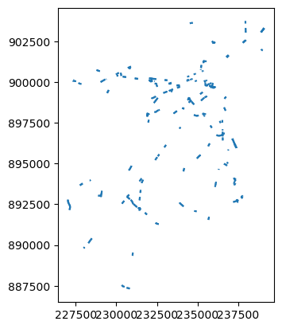

```python
suitable_roads.clip(secured_areas,keep_geom_type=False).plot()
```

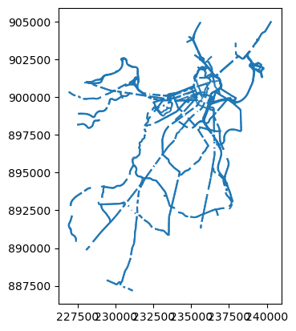

```python
suitable_roads.overlay(secured_areas,keep_geom_type=False, how='difference').plot()
```

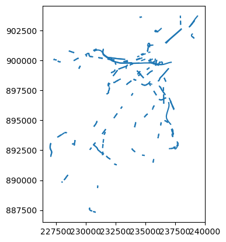

```python
suitable_roads.sjoin(secured_areas, predicate='intersects').plot()
```

Why **clip** is a poor choice?

- Keeps only the parts that overlap with the mask. We want the opposite - to remove the overlapping parts (this would give you only roads inside school zones (the exact opposite!))

Why **sjoin** is a poor choice?

- You do get the precise locations that should not be included, you get the whole row element (more area). Since sjoin does not have a **not-intersects** predicate, this will also be wrong:

```
bad_geoms = suitable_roads.clip(secured_areas)
good_segments = suitable_roads.overlay(bad_geoms, how='difference')
```

Then:

```python
good_routes_forGas_dissolved=suitable_roads.overlay(secured_areas,keep_geom_type=False, how='difference').dissolve()
good_routes_forGas=gpd.GeoDataFrame(geometry=good_routes_forGas_dissolved.geometry)
good_routes_forGas
```

|  | geometry |
| --- | --- |
| 0 | MULTILINESTRING ((236538.63 896605.726, 236537... |

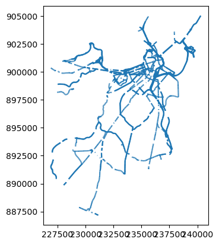

```python
good_routes_forGas.plot()
```

We may choose a location from those places:

```python
# newCOMPETITORS=safe_fuelCompetitors_gdf.copy()
potential_Locations=good_routes_forGas.copy()
newPOLYGONS=[]
pointsComputed=1
attempts=1
while pointsComputed<=len(gas_relocate):
  candidatePoint=potential_Locations.sample_points(1)
  candidateStation=gpd.GeoDataFrame(geometry=candidatePoint.buffer(100))
  if candidateStation.overlay(secured_areas,how='intersection',keep_geom_type=False).empty:
    newPOLYGONS.append(candidateStation)
    pointsComputed+=1
    potential_Locations=potential_Locations.overlay(candidateStation, how='difference', keep_geom_type=False)
  if attempts>len(gas_relocate)*10:
    break
  attempts+=1

# some info
attempts,len(newPOLYGONS)
```

```
(10, 7)
```

```python
newPOLYGONS
```

```
[                                            geometry
 0  POLYGON ((234744.193 892128.907, 234743.712 89...,
                                             geometry
 0  POLYGON ((237056.144 900944.13, 237055.662 900...,
                                             geometry
 0  POLYGON ((239098.604 902147.714, 239098.122 90...,
                                             geometry
 0  POLYGON ((231349.593 901214.011, 231349.111 90...,
                                             geometry
 0  POLYGON ((230097.302 894051.15, 230096.82 8940...,
                                             geometry
 0  POLYGON ((234130.963 899754.455, 234130.482 89...,
                                             geometry
 0  POLYGON ((233275.845 893859.029, 233275.363 89...]
```

```python
pd.concat(newPOLYGONS)
```

|  | geometry |
| --- | --- |
| 0 | POLYGON ((234744.193 892128.907, 234743.712 89... |
| 0 | POLYGON ((237056.144 900944.13, 237055.662 900... |
| 0 | POLYGON ((239098.604 902147.714, 239098.122 90... |
| 0 | POLYGON ((231349.593 901214.011, 231349.111 90... |
| 0 | POLYGON ((230097.302 894051.15, 230096.82 8940... |
| 0 | POLYGON ((234130.963 899754.455, 234130.482 89... |
| 0 | POLYGON ((233275.845 893859.029, 233275.363 89... |

```python
GoodLocationsGas_buffered_gdf=pd.concat(newPOLYGONS)
GoodLocationsGas_gdf=gpd.GeoDataFrame(geometry=GoodLocationsGas_buffered_gdf.centroid)
```

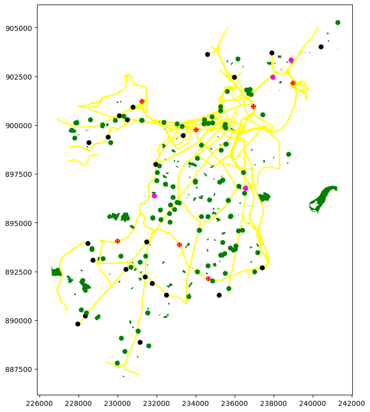

```python
# original suitable roads
base = suitable_roads.plot(color='yellow', figsize=(10, 10),zorder=1)

# non-overlapping buffers
GoodLocationsGas_buffered_gdf.plot(ax=base, edgecolor='red', marker="+", facecolor='none',zorder=2)

# center points of the buffers
GoodLocationsGas_gdf.plot(ax=base, color='red', marker="+", markersize=50,zorder=3)

# all stations
fuelBoston.plot(ax=base,color='k',zorder=4)
schoolBoston.plot(ax=base,color='green',zorder=5)

# stations to relocate
fuelBoston.clip(gas_relocate).plot(ax=base,color='magenta',zorder=5)
```

## Reverse geocoding

Just get some addresses:

```python
from geopy.geocoders import Nominatim
import time

# Initialize geocoder
geolocator = Nominatim(user_agent="boston_gas_stations")

def get_address(point):
  # Now coordinates are in degrees (lon, lat)
  lon = point.x
  lat = point.y
  location = geolocator.reverse((lat, lon), exactly_one=True, timeout=10)
  time.sleep(1)  # Rate limiting

  if location:
    return location.address
  else:
    return None # not found
```

```python
# Get addresses
GoodLocationsGas_4326 = GoodLocationsGas_gdf.to_crs('EPSG:4326')
GoodLocationsGas_gdf['address'] = GoodLocationsGas_4326.geometry.apply(get_address)
```

```python
GoodLocationsGas_gdf
```

|  | geometry | address |
| --- | --- | --- |
| 0 | POINT (234644.193 892128.907) | 1006, Morton Street, Mattapan, Boston, Suffolk... |
| 0 | POINT (236956.144 900944.13) | Atlantic Avenue, Waterfront, North End, Boston... |
| 0 | POINT (238998.604 902147.714) | Airport Road - Arrivals Level, Jeffries Point,... |
| 0 | POINT (231249.593 901214.011) | Harvard University, Mount Auburn Street, Cambr... |
| 0 | POINT (229997.302 894051.15) | 10, Veterans of Foreign Wars Parkway, West Rox... |
| 0 | POINT (234030.963 899754.455) | Patrolman James B. O'Leary Bridge, Massachuset... |
| 0 | POINT (233175.845 893859.029) | 379, Morton Street, Forest Hills, Roxbury, Bos... |

[BACK TO MAIN MENU](https://cienciadedatosespacial.github.io/GDF_OPS_applications/)